# Lab 4

#Introduction and Set-Up

#Summary

```
## Rows: 6,083
## Columns: 14
## $ X1             <dbl> 5, 7, 43, 27, 19, 6, 4, 38, 32, 31, 21, 0, 38, 0, 52, 2…
## $ Date           <chr> "11/22/15", "11/12/17", "3/1/15", "6/21/15", "8/16/15",…
## $ AveragePrice   <dbl> 0.98, 1.56, 1.09, 1.02, 1.88, 1.25, 1.09, 0.97, 1.65, 1…
## $ `Total Volume` <dbl> 215985.17, 19100.44, 1619341.49, 35734613.90, 32159.33,…
## $ `4046`         <dbl> 87241.86, 204.09, 854129.32, 14699604.93, 5368.34, 5776…
## $ `4225`         <dbl> 91574.86, 163.45, 460986.95, 13244466.60, 15506.11, 731…
## $ `4770`         <dbl> 3926.84, 6.77, 11417.67, 1326422.56, 35.65, 998.99, 100…
## $ `Total Bags`   <dbl> 33241.61, 18726.13, 292807.55, 6464119.81, 11249.23, 24…
## $ `Small Bags`   <dbl> 31653.96, 18711.27, 291293.85, 5517909.51, 9695.15, 124…
## $ `Large Bags`   <dbl> 1587.65, 14.86, 540.74, 898027.46, 1554.08, 12406.71, 3…
## $ `XLarge Bags`  <dbl> 0.00, 0.00, 972.96, 48182.84, 0.00, 10.22, 53201.00, 0.…
## $ type           <chr> "conventional", "organic", "conventional", "conventiona…
## $ year           <dbl> 2015, 2017, 2015, 2015, 2015, 2015, 2017, 2016, 2016, 2…
## $ region         <chr> "LasVegas", "HarrisburgScranton", "Plains", "TotalUS", …
```

#Describe the Dataset There are 6083 rows and 14 columns in this dataset, representing information on avocados in different regions for every week from 1/4/2015-3/25/18. This information includes average prices, number of different sizes of avocados sold, and number of different types of bags sold. The data were collected in 2018 through retailers’ cash registers based on sales of Hass avocados.

#Clean the Dataset: Major Regions

#Clean the Dataset: Cities

#Clean the Dataset: minor_regions

#Clean the Dataset: Total US

#1. Which major region sold the most organic, small Hass avocados in 2017? West is the major region that sold the most Haas Avocados.

```
## # A tibble: 1 × 2
##   region sum_total
##   <chr>      <dbl>
## 1 West     734399.
```

#2. Use the separate() function to split the Date variable into year, month, and day. In which month is the highest volume of avocado sales? January is the month with the highest volume of avocado sales.

```
## # A tibble: 1 × 2
##   Month  sum_month
##   <chr>      <dbl>
## 1 1     641550323.
```

#3. Which metro area regions sold the most total avocados? Plot side-by-side boxplots of total volume for only the five regions with the highest averages for the Total Volume variable. Los Angeles, PhoenixTucson, DallasFtWorth, Houston, and Baltimore Washington are the metro regions that sold the more total avocados.

```
## # A tibble: 5 × 2
##   region              sum_total_city
##   <chr>                        <dbl>
## 1 LosAngeles              138052320.
## 2 PhoenixTucson            68691354.
## 3 DallasFtWorth            62595467.
## 4 Houston                  59805984.
## 5 BaltimoreWashington      48647013.
```

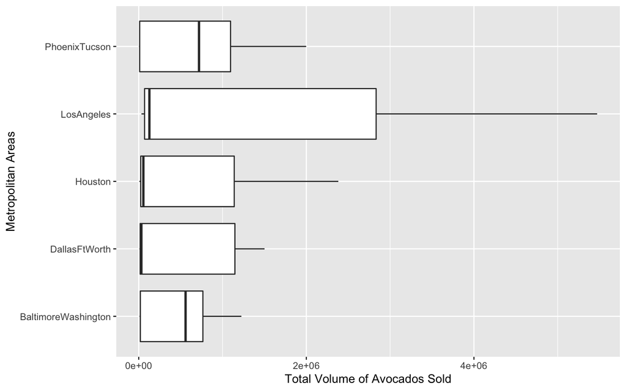

#Reshaping

#1.In which regions is the price of organic versus conventional avocados most different? Support your answer with a few summary statistics and a visualization. The region in California with the largest mean price difference between organic and conventional avocados is San Francisco.

```
## # A tibble: 4 × 4
## # Groups:   region [4]
##   region       conventional organic difference
##   <chr>               <dbl>   <dbl>      <dbl>
## 1 LosAngeles          0.960    1.46      0.502
## 2 Sacramento          1.28     1.97      0.688
## 3 SanDiego            1.04     1.72      0.685
## 4 SanFrancisco        1.39     2.25      0.850
## # A tibble: 8 × 3
## # Groups:   region [4]
##   region       type         `median(AveragePrice)`
##   <chr>        <chr>                         <dbl>
## 1 LosAngeles   conventional                   0.95
## 2 LosAngeles   organic                        1.37
## 3 Sacramento   conventional                   1.28
## 4 Sacramento   organic                        1.97
## 5 SanDiego     conventional                   1.01
## 6 SanDiego     organic                        1.7
## 7 SanFrancisco conventional                   1.38
## 8 SanFrancisco organic                        2.30
```

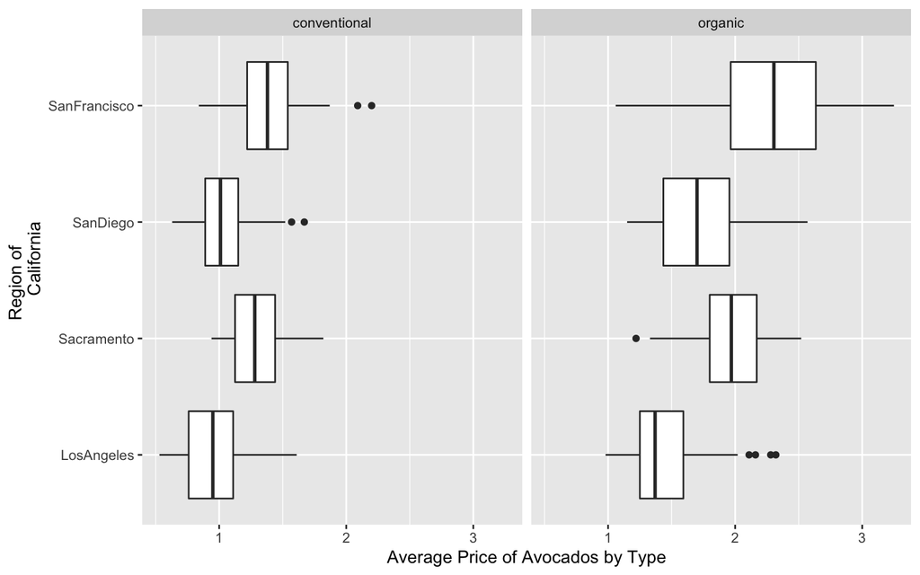

#2. The following plot shows, for all four California regions, the proportion of the mean Hass avocado sales that are small, large, or extra large; conventional vs. organic. Recreate the plot.

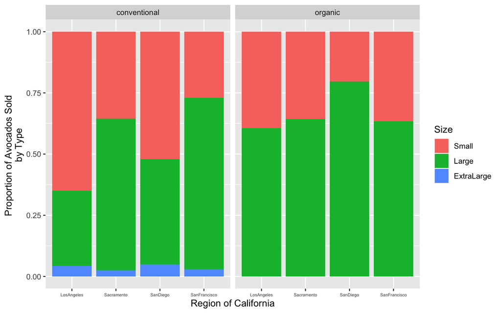

#Challenge I got the dataset from kaggle. The dataset in kaggle was sourced from Zillow and it contained the home prices for many cities in the US from 2011 through 2020. link:https://www.kaggle.com/paultimothymooney/zillow-house-price-data

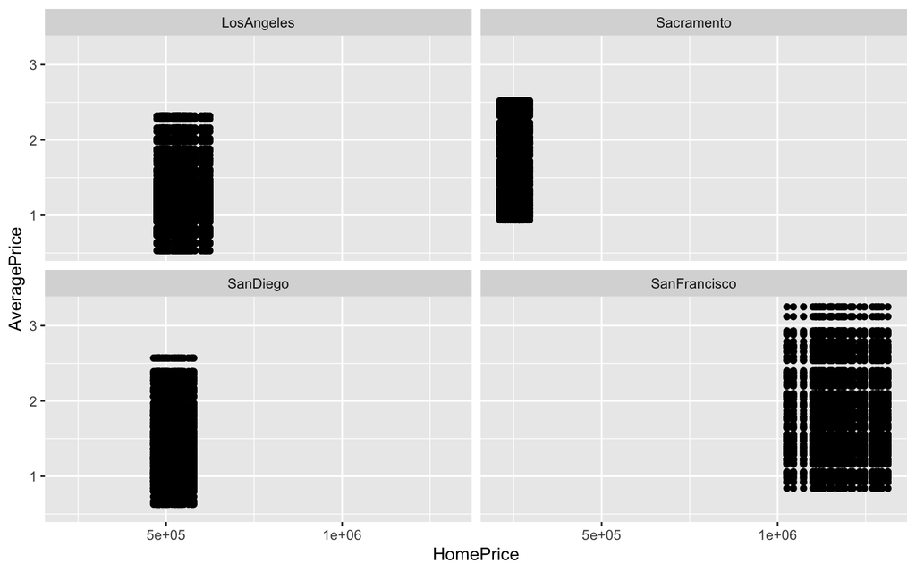

```r
CA_housing <- house_price %>%
  filter(RegionName %in% c("Los Angeles", "San Diego",
                       "Sacramento","San Francisco"))

CA_housing <- CA_housing %>%
  mutate(RegionName = if_else(RegionName == 'Los Angeles',
                              'LosAngeles', RegionName))

CA_housing <- CA_housing %>%
  mutate(RegionName = if_else(RegionName == 'San Diego',
                              'SanDiego', RegionName))

CA_housing <- CA_housing %>%
  mutate(RegionName = if_else(RegionName == 'San Francisco',
                              'SanFrancisco', RegionName))

CA_housing <- CA_housing %>%
  rename(region = RegionName)

housing_avocados <- CA_avocado %>%
  inner_join(CA_housing, by = "region")

housing_avocados <- housing_avocados %>%
  select(`2015-01`:`2018-03`, region, AveragePrice)

housing_avocados <- housing_avocados %>%
  pivot_longer(`2015-01`:`2018-03`,
             names_to = 'Date',
             values_to = 'HomePrice')

housing_avocados %>%
  ggplot(mapping = aes(x = HomePrice, y = AveragePrice)) +
  geom_point() +
  facet_wrap(~ region)
```

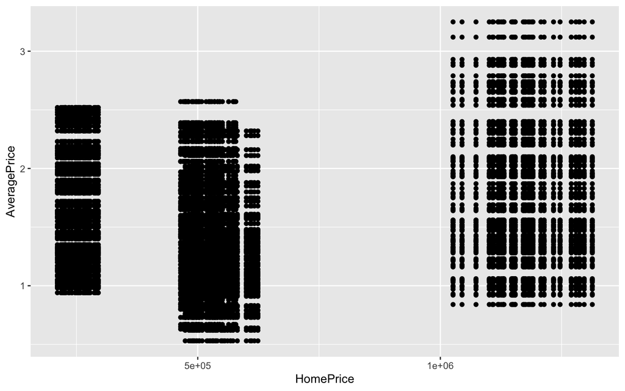

```r
housing_avocados %>%
  ggplot(mapping = aes(x = HomePrice, y = AveragePrice)) +
  geom_point()
```